# Cue-task macBP gamma & event-locked spectrograms

### 6.2 Participants with a detectable gamma peak, per epoch

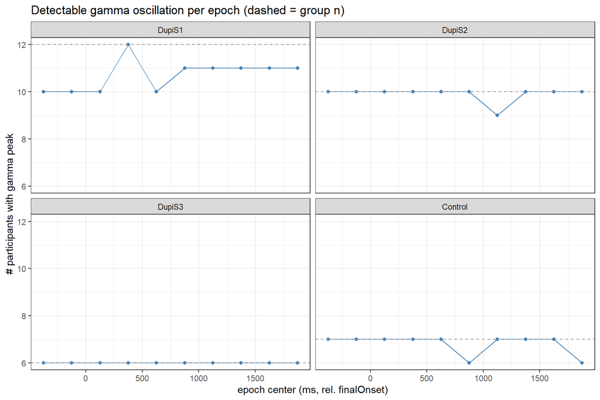

### 6.3 Channel-centered gamma peak frequency across epochs

Group average (red) with each participant shown as lighter connected dots.

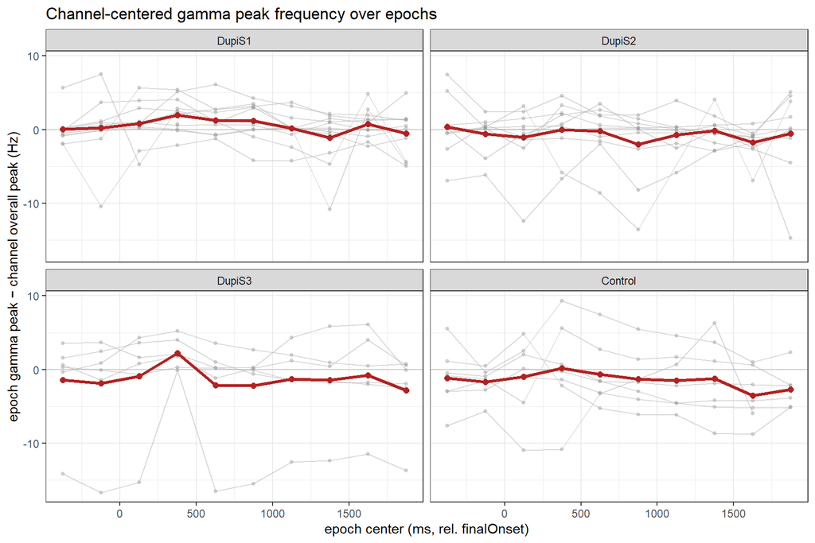

### 6.4 Does gamma peak frequency change over epochs? (LME per group)

Linear mixed-effects model `gammaPeakFreq ~ epoch + (1|subject)`, fit within each group; epochs with no FOOOF-detected gamma peak are treated as missing.

LME: gamma peak frequency ~ epoch + (1|subject), per group (slope = Hz per 250 ms epoch).

| group | n_obs | n_subj | slope_Hz_per_epoch | SE | t | p |
| --- | --- | --- | --- | --- | --- | --- |
| DupiS1 | 107 | 12 | -0.1250 | 0.0819 | -1.5257 | 0.1305 |
| DupiS2 | 99 | 10 | -0.0992 | 0.0983 | -1.0089 | 0.3158 |
| DupiS3 | 60 | 6 | -0.1096 | 0.1174 | -0.9335 | 0.3548 |
| Control | 68 | 7 | -0.2253 | 0.1378 | -1.6351 | 0.1073 |

### 6.5 Does gamma frequency track gamma power across epochs?

Each epoch’s gamma peak is expressed **relative to the channel’s whole-recording (overall) FOOOF peak** (§3), by **subtraction** — the appropriate operation given the metrics:

- **Δ frequency** = epoch peak − overall peak (Hz). Subtraction (not a ratio) because frequency is interval-scaled; this also removes each individual’s characteristic gamma frequency.
- **Δ power** = epoch peak height − overall peak height. `gammaPeakPower` is the FOOOF peak **height above the 1/f aperiodic** (log10 power), so it is already aperiodic-/SNR-corrected and its differences are ≈ dB changes; subtracting log-heights is the natural “change.”

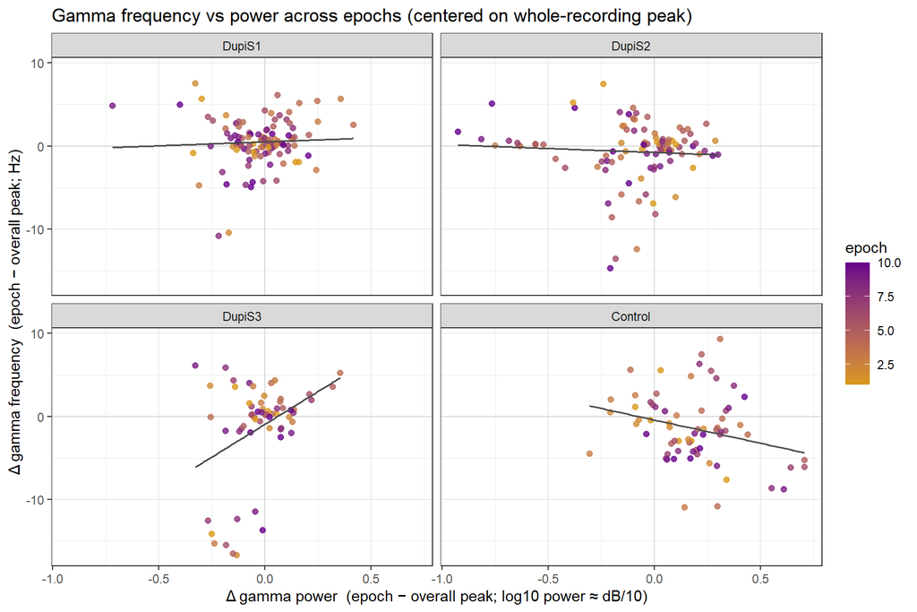

Within-session coupling via a linear mixed-effects model `Δfreq ~ Δpower + (Δpower|session)`, fit per group (random slope; falls back to random intercept if the slope variance is singular). The slope is the within-session change in gamma frequency (Hz) per unit change in gamma power (log10).

Within-session LME: Δfreq ~ Δpower + (Δpower|session), per group.

| group | n_obs | n_subj | model | slope_Hz_per_logPow | SE | t | p |
| --- | --- | --- | --- | --- | --- | --- | --- |
| DupiS1 | 107 | 12 | rand.slope | 2.0432 | 2.4563 | 0.8318 | 0.4249 |
| DupiS2 | 99 | 10 | rand.intercept | -0.8687 | 2.0142 | -0.4313 | 0.6677 |
| DupiS3 | 60 | 6 | rand.slope | -4.0335 | 5.0670 | -0.7960 | 0.4599 |
| Control | 68 | 7 | rand.intercept | -4.8258 | 2.3209 | -2.0793 | 0.0415 |